# Ford GoBike Trips Analysis

## Investigation Overview

In this investigation, I wanted to look at Ford GoBike trips data and analyze the behavioral of the users. The main focus was on:

- The number of trips
- The trip duration
- The trip distance
- The members user type
- The members age

## Dataset Overview

There are 183,412 trips in the dataset (after data cleaning) mainly about the bike trips information such as trip duration and many member information like member age, gender and user type.

## Ford GoBike Members Behavior

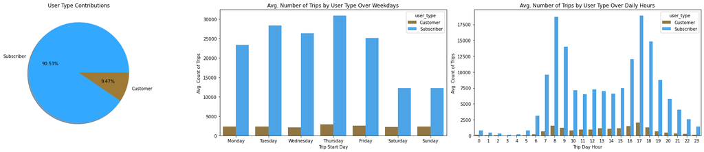

## Trip Duration and Distance

Although the average number of trips is in favor of the subscribers' contribution, the ad-hoc customers on average take longer and farther trips than the subscribers.

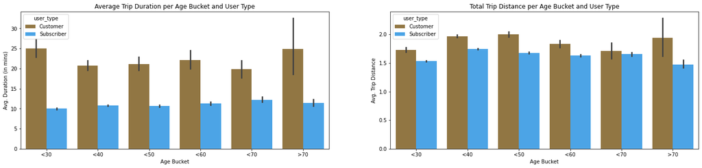

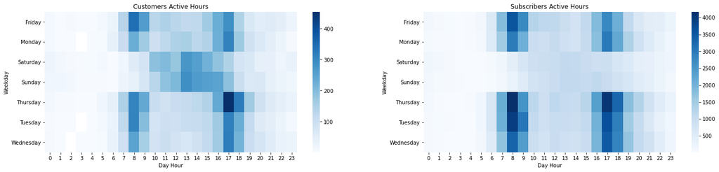

## Recommendations

We can conclude that Ford GoBike company has potential subscribers to work on their retention. The customers using the bikes for longer time and farther distance mainly on weekends, and the subscribers use the bikes along the working days for shorter time, nearer distance and more frequent than the customers.

[output not shown]